# Exploring Relationships of Physical and Socioeconomic Factors Associated with Water Temperature.

Cammie Moore, Jack Killeen, Shaochong Xue

2025-04-04

*Link to GitHub repository:https://github.com/AllenX0627/MooreXueKilleen.git*

### Research Question

How is stream water temperature related to physical and socioeconomic factors such elevation, income, and concentration of heavy industry?

### Exploring Data

Census data was collected from the 2023 ACS 5-year community survey. Socioeconomic factors such as median income, employment, and total population were analyzed to explore their potential relationship with water temperatures recorded at various USGS gauges across North Carolina, Tennessee, South Carolina, and Georgia. Water temperature data were collected from April 1st to April 2nd and averaged to obtain the mean temperature (in Celsius) for that period.

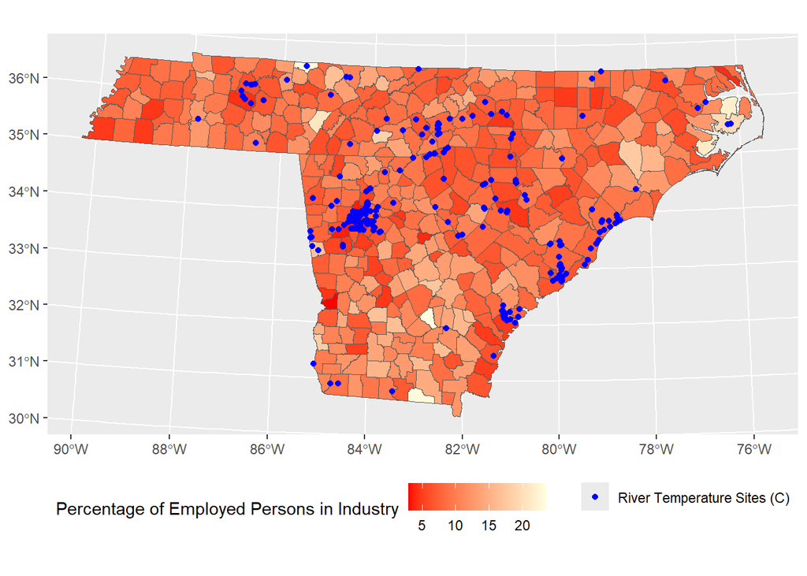

Figure 1. Exploring River Sites and Percentage of Populations in Industry

As shown in exploratory Figure 1, there are varying degrees of industry (defined as employment in construction, manufacturing, or mining) across Georgia, North Carolina, South Carolina, and Tennessee. There appears to be a concentration of river gauges in northern Georgia near Atlanta. There may be spatial autocorrelation to take into consideration due to this concentration of data.

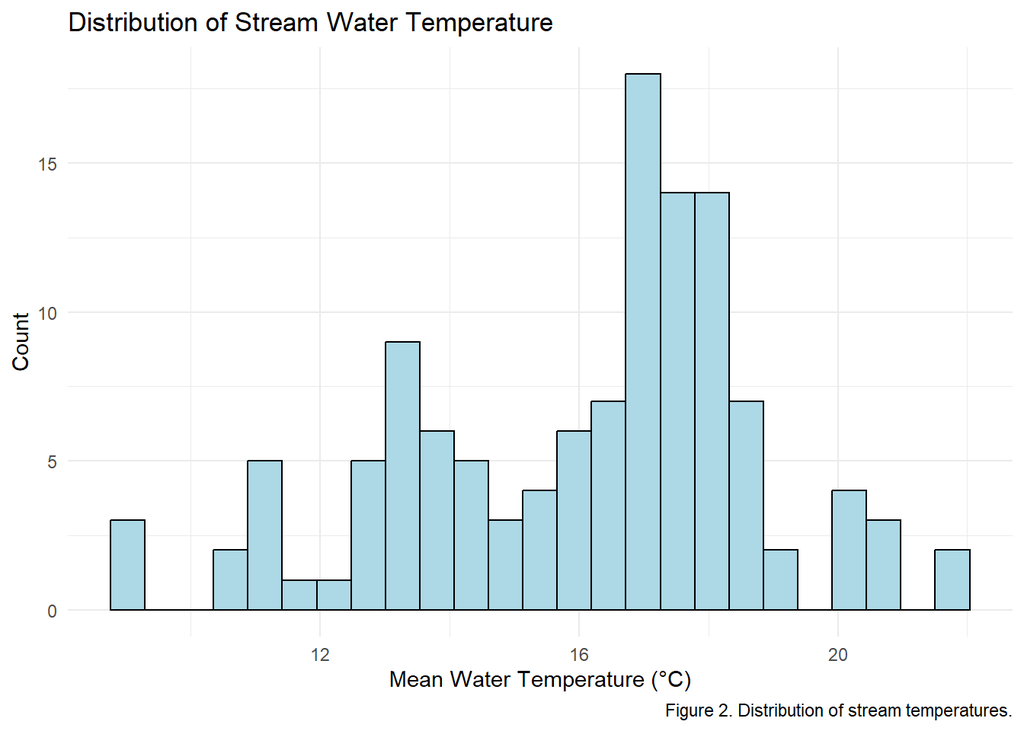

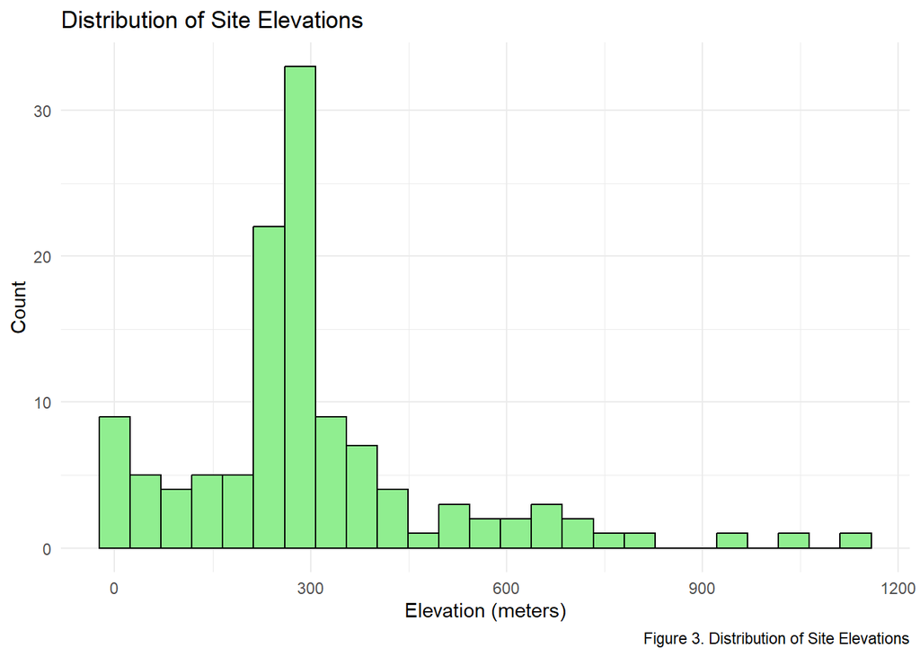

[interactive chart not shown]

Figure 4. Water gauge sites spatially located in study states with mean water temperature from April 1st - April 2nd, 2025.

### Data Structure Table

Table 1. Summary of Variables Used in the Analysis

| Variable | Unit | Range | Mean | Source |
| --- | --- | --- | --- | --- |
| mean_temp_C | °C | 9.1–21.8 | 16.0 | USGS stream data |
| mean_t_air | °C | 9.1–22.4 | 15.7 | PRISM climate data |
| mean_flow | cfs | 0.7–10150 | 788.9 | USGS stream data |
| log_flow | log(cfs) | -0.3–9.2 | 4.7 | Calculated |
| elevation | meters | 3–1138 | 301.0 | AWS Elevation API |
| log_elev | log(meters) | 1.1–7 | 5.4 | Calculated |
| total_pop | people | 8041–1068507 | 407705.0 | US Census ACS |
| med_income | USD | 41200–138000 | 73901.0 | US Census ACS |
| per_pov | % | 4.5–24.9 | 13.1 | US Census ACS |
| per_industry | % | 3.5–18.5 | 7.2 | US Census ACS |

### Linear Regressions

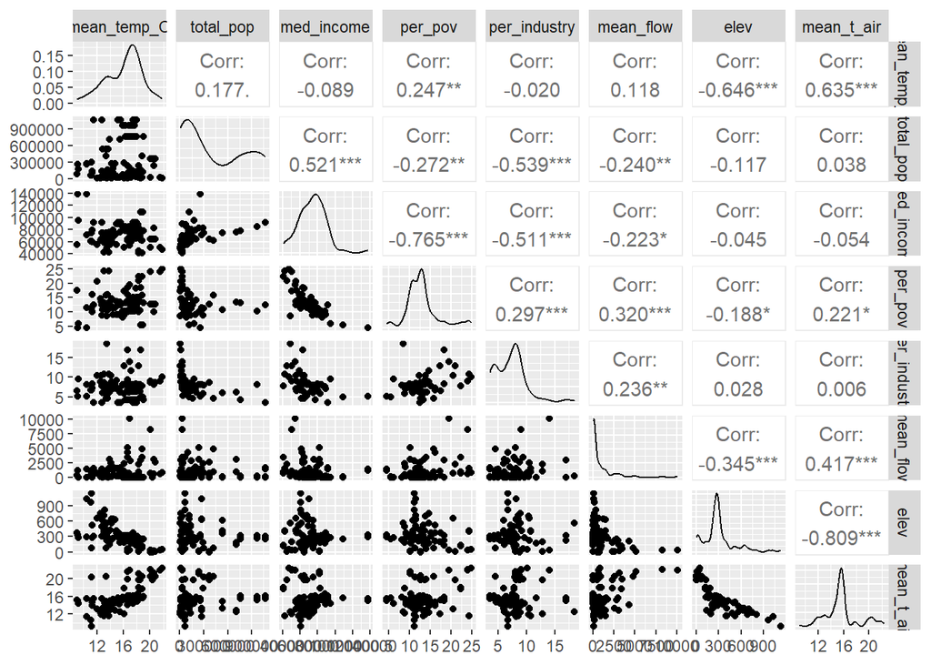

Figure 2. Scatterplot matrix of water temperature and predictors

As shown in Figure.2:

Air temperature is positively correlated with water temperature (r = 0.635).

Elevation is negatively correlated with water temperature (r = -0.646).

Poverty rate shows a weak positive correlation with water temperature (r = 0.247).

Other variables, such as flow, industrial employment percentage, and median income, do not show significant correlations with water temperature.

Elevation and flow are highly skewed, we applied log transformations to improve linearity for regression.

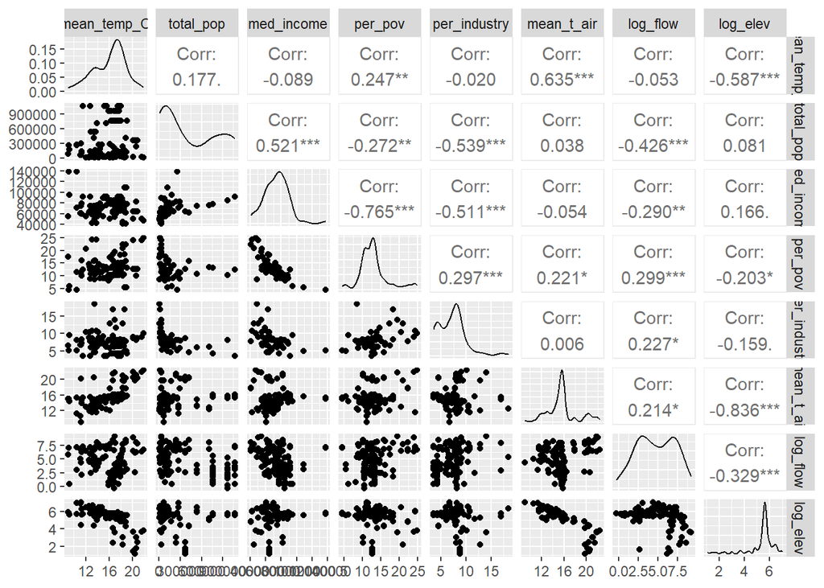

Figure 3. Scatterplot matrix of water temperature and predictors (log transformed)

AS shown in Figure 3, after applying log transformations to elevation and flow, the overall patterns in the scatterplot matrix did not change much.

According to the linear model, air temperature, stream flow, elevation, and poverty rate were significant predictors of water temperature.

Every 1°C increase in air temperature is associated with 0.35°C increased in water temperature (p = 0.0124).

Every 1% increase in the flow is associated with 0.0034°C decrease in water temperature (p = 0.00019).

Every 1% increase in the poverty rate is associated with 0.18°C increase in water temperature (p = 0.0213).

Industrial employment and median income were not significantly related to water temperature.

The model explained about 48% of the variation in water temperature across our study sites (Adjusted R² = 0.478), suggesting a moderately strong fit.

VIF values for all predictors were below 5, indicating no serious multicollinearity concerns in the model.

We used AIC to select variables, reducing the linear regression model.The final model included air temperature, flow, elevation, and poverty rate as predictors.

The reduced model has a slightly higher Adjusted R² (0.480 vs 0.478) and lower AIC (514 vs 517), indicating a better fit with fewer predictors.

### Difference Test

Based on the U.S. Census Bureau (2023) report, the median household income in the United States was $74.580.

Therefore, to further explore the relationship between income levels and water temperature, we classified our data into two groups: “High Income” (median income ≥ 74.580) and “Low Income” (median income < 74.580).

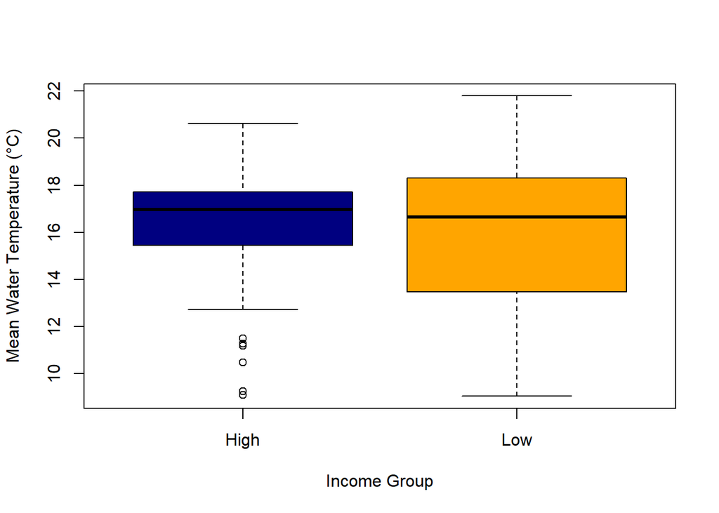

Figure 4: Stream Water Temperature by Income Group

Based on the Shapiro-Wilk test results, water temperature data for the high income group significantly deviates from a normal distribution. Therefore, we used the Wilcoxon test to compare water temperatures between the two income groups.

The result of Wilcoxon test was not statistically significant (p = 0.903), indicating that water temperature did not differ significantly between high-income and low-income sites.

### Summary and Conclusions

Our analysis shows that air temperature, elevation, stream flow, and poverty rate are significant predictors of river water temperature in the southeastern United States. Specifically, water temperature increases with higher air temperature and poverty rate, and decreases with higher elevation and stream flow. However, when comparing sites grouped by income level, no statistically significant difference in water temperature was found.

While industrial activity is commonly associated with thermal pollution and elevated air temperatures, our study did not find its significant relationship with water temperature. This may be due to several reasons:

1. The industrial employment variable used was broad and may not reflect actual thermal discharges.
2. Most sites likely comply with environmental regulations that limit heated water discharge.
3. Stream temperature is strongly influenced by physical factors such as air temperature and elevation, which may overshadow weaker socioeconomic effects.

#### Data Citation

Oliver, S.K., Appling, A., Watkins, D., Atshan, R., and Read, J., 2024, Compilation of multi-agency water temperature observations for U.S. streams, 1894-2022: U.S. Geological Survey data release, https://doi.org/10.5066/P9EMWZ35.